# Predicting Airbnb Booking Popularity in Washington, DC

## Project Overview

This project explores a dataset of Airbnb listings in Washington, DC, to predict whether a listing has a “high booking rate,” indicating frequent bookings.

### Objectives

- **EDA & Cleaning:** Explore the data to understand structure, discover patterns, and handle missing values.
- **Model Development:** Build linear and logistic regression models to predict the target variable, `high_booking_rate`.
- **Interpretation & Insights:** Identify key features influencing booking popularity.
- **Model Evaluation:** Validate model performance on training and testing sets using relevant classification metrics.

### Dataset Description

The dataset includes 4,936 Airbnb listings with property details, location, and booking information. The goal is to predict `high_booking_rate`, showing the likelihood of a listing being frequently booked.

### Approach

- **Exploration & Visualization:** Identify key trends using Python.
- **Modeling:** Develop regression models, applying feature engineering to improve accuracy.
- **Validation:** Evaluate models based on metrics like accuracy, precision, recall, and AUC.

This project enhances my skills in data exploration, modeling, and predictive analysis within the short-term rental market context.

```r
airbnb <- read_csv("dc_airbnb_hw1.csv")  #read the dataset in R
names(airbnb)                       #variables used in dataset
```

```
##  [1] "name"                      "accommodates"
##  [3] "bed_type"                  "bedrooms"
##  [5] "beds"                      "cancellation_policy"
##  [7] "cleaning_fee"              "host_total_listings_count"
##  [9] "price"                     "property_type"
## [11] "room_type"                 "high_booking_rate"
```

```r
age_mean <- airbnb %>%
  summarise(mean_accommodates = mean(accommodates))
```

## 1: EDA and Data Cleaning

### a) To prepare the dataset for analysis, the following cleaning and preprocessing steps were performed:

- **Cancellation Policy Grouping:** Combined the `"strict"` and `"super_strict_30"` categories into a single `"strict"` category to simplify analysis.
- **Convert to Numeric:** Transformed `cleaning_fee` and `price` into numeric values.
- **Handling Missing Values (NAs):**
  - Replaced missing values in `cleaning_fee` and `price` with `0`.
  - Imputed missing values in other numeric variables with their mean.

```r
data_airbnb_clean <- airbnb %>%
  mutate(cancellation_policy = ifelse(cancellation_policy %in% c("strict", "super_strict_30"), "strict", cancellation_policy),
   cleaning_fee = as.numeric(gsub("[$,]", "", cleaning_fee)),
   price = as.numeric(gsub("[$,]", "", price)),
   cleaning_fee = ifelse(is.na(cleaning_fee), 0, cleaning_fee),
   price = ifelse(is.na(price), 0, price)
  )

num_cols <- c("accommodates", "bedrooms", "beds", "host_total_listings_count")

data_airbnb_clean <- data_airbnb_clean %>%
  mutate_at(num_cols, ~replace_na(., mean(., na.rm = TRUE)))
```

### b) Feature Engineering: Creating New Variables

To enhance the dataset, the following new variables were created:

- **price_per_person:** Calculated as the nightly `price` divided by the `accommodates`, representing the cost per person per night.
- **has_cleaning_fee:** A binary variable indicating whether a cleaning fee exists. Coded as `"YES"` if `cleaning_fee` > 0, `"NO"` otherwise.
- **bed_category:** A categorical variable with values `"bed"` if `bed_type` is `"Real Bed"` and `"other"` for all other bed types.
- **property_category:** Categorized based on the `property_type`:
  - `"apartment"` for `"Apartment"`, `"Serviced apartment"`, or `"Loft"`.
  - `"hotel"` for `"Bed & Breakfast"`, `"Boutique hotel"`, or `"Hostel"`.
  - `"condo"` for `"Townhouse"` or `"Condominium"`.
  - `"house"` for `"Bungalow"` or `"House"`.
  - `"other"` for any other property types. This variable was converted to a factor for analysis.
- **ppp_ind:** A binary indicator where `1` denotes that `price_per_person` is greater than the median `price_per_person` within its `property_category`, and `0` otherwise.

```r
data1 <- data_airbnb_clean %>%
  mutate(
    price_per_person = price/accommodates,
    has_cleaning_fee = ifelse(cleaning_fee > 0, 'YES', 'NO'),
    bed_category = ifelse(bed_type == "Real Bed", "bed", "other"),
    property_category = case_when(
      property_type %in% c("Apartment", "Serviced apartment", "Loft") ~ "apartment",
      property_type %in% c("Bed & Breakfast", "Boutique hotel", "Hostel") ~ "hotel",
      property_type %in% c("Townhouse", "Condominium") ~ "condo",
      property_type %in% c("Bungalow", "House") ~ "house",
      TRUE ~ "other") ) %>%
  group_by(property_category) %>%
  mutate(
    ppp_ind = ifelse(price_per_person > median(price_per_person), 1, 0)
  ) %>%
  ungroup() %>%
  mutate(
    property_category = factor(property_category, levels = c("apartment", "hotel", "condo", "house", "other"))
  )
```

### c) Converting the remaining character variables to factors:

- bed_type
- cancellation_policy
- room_type

```r
data2 <- data1 %>%
  mutate(
    bed_type = factor(bed_type),
    cancellation_policy = factor(cancellation_policy),
    room_type = factor(room_type) )
```

### d) Visualizing Price Per Person by Booking Rate

To examine the relationship between the nightly price per person and the booking rate, boxplots were constructed for both `price_per_person` and `log(price_per_person)`, grouped by `high_booking_rate`.

- **Boxplots of `price_per_person`:** The distribution of prices per person is visualized across different values of `high_booking_rate`.
- **Boxplots of `log(price_per_person)`:** A logarithmic transformation is applied to `price_per_person` to better visualize the distribution and reduce the effect of outliers.

**Observations:**

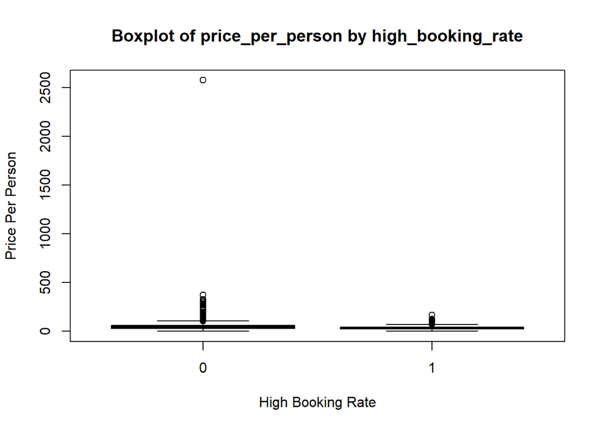

```r
library(ggplot2)

#boxplot of price_per_person
boxplot(price_per_person ~ high_booking_rate, data = data2,
        main = "Boxplot of price_per_person by high_booking_rate",
        xlab = "High Booking Rate",
        ylab = "Price Per Person",
        col = "red")
```

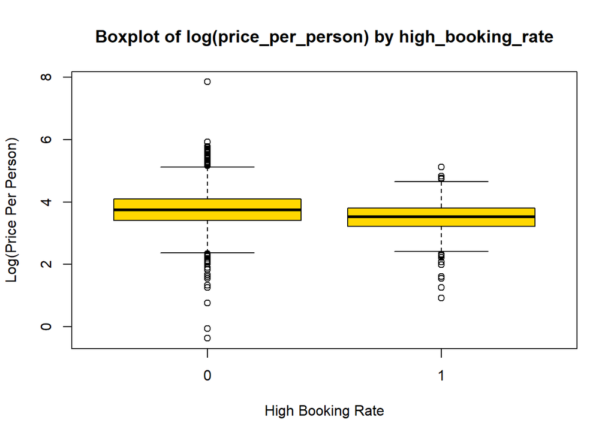

```r
#boxplot of log(price_per_person)
boxplot(log(price_per_person) ~ high_booking_rate, data = data2,
        main = "Boxplot of log(price_per_person) by high_booking_rate",
        xlab = "High Booking Rate",
        ylab = "Log(Price Per Person)",
        col = "gold")
```

**Observations:** There appears to be negative relationship between price_per_person and high_booking_rate.

### e) To explore how booking rates vary across property types, a two-way table was constructed between `high_booking_rate` and `property_category`.

```r
#two way table
high_book_rate_2way_t <- table(data2$high_booking_rate, data2$property_category)
high_book_rate_2way_t
```

```
##
##     apartment hotel condo house other
##   0      2013    50   387  1198    50
##   1       672    12   171   363    20
```

```r
#prop table
high_book_rate_prop_t <- prop.table(high_book_rate_2way_t, margin = 2)
high_book_rate_prop_t
```

```
##
##     apartment     hotel     condo     house     other
##   0 0.7497207 0.8064516 0.6935484 0.7674568 0.7142857
##   1 0.2502793 0.1935484 0.3064516 0.2325432 0.2857143
```

## 2: Linear Regression

### a) Training a linear regression to predict high_booking_rate using the variables listed below.

- cancellation_policy
- cleaning_fee
- price_per_person
- ppp_ind
- has_cleaning_fee
- accommodates
- bed_category
- bedrooms
- beds
- host_total_listings_count
- property_category

```r
model1 <- lm(high_booking_rate ~ cancellation_policy + cleaning_fee + price_per_person + ppp_ind + has_cleaning_fee + accommodates + bed_category + bedrooms + beds + host_total_listings_count + property_category, data = data2)

summary(model1)$r.squared
```

```
## [1] 0.07898232
```

### b) Given a set of listing characteristics, the goal is to predict the `high_booking_rate`. The prediction is based on the model built earlier in the analysis.

New Listing:

- cancellation_policy = super_strict_30
- cleaning_fee = $30
- price = $200
- accommodates = 4
- bed_type = Real Bed
- bedrooms = 3
- beds = 4
- host_total_listings_count = 1
- property_type = townhouse

```r
new_listing <- data.frame(cancellation_policy = "strict",
                          cleaning_fee = 30, price_per_person = 200/4,
                          ppp_ind = 1, has_cleaning_fee = "YES",
                          accommodates = 4,
                          bed_category = "other",
                          bedrooms = 3,
                          beds = 4,
                          host_total_listings_count = 1,
                          property_category = "condo"
)



high_booking_rate_pred <- predict(model1, newdata = new_listing)
high_booking_rate_pred
```

```
##         1
## 0.2602891
```

The high_booking_rate prediction value for the new listing, was closer to 0 than it is to 1, which suggests that our model has predicted that this new listing will not have a high booking rate.

## 3: Logistic Regression

### a) Training a Logistic Regression model using the same variables as in Linear Regression model:

```r
model1_logit <- glm(high_booking_rate ~ cancellation_policy + cleaning_fee + price_per_person + ppp_ind + has_cleaning_fee + accommodates + bed_category + bedrooms + beds + host_total_listings_count + property_category, data = data2, family = binomial)
summary(model1_logit)
```

```
##
## Call:
## glm(formula = high_booking_rate ~ cancellation_policy + cleaning_fee +
##     price_per_person + ppp_ind + has_cleaning_fee + accommodates +
##     bed_category + bedrooms + beds + host_total_listings_count +
##     property_category, family = binomial, data = data2)
##
## Coefficients:
##                              Estimate Std. Error z value Pr(>|z|)
## (Intercept)                 -0.978980   0.160907  -6.084 1.17e-09 ***
## cancellation_policymoderate  0.510296   0.093378   5.465 4.63e-08 ***
## cancellation_policystrict    0.444980   0.095816   4.644 3.42e-06 ***
## cleaning_fee                -0.006897   0.001299  -5.308 1.11e-07 ***
## price_per_person            -0.019105   0.002891  -6.608 3.91e-11 ***
## ppp_ind                     -0.053136   0.108611  -0.489   0.6247
## has_cleaning_feeYES          0.841786   0.107402   7.838 4.59e-15 ***
## accommodates                 0.040726   0.035167   1.158   0.2468
## bed_categoryother           -0.264513   0.208151  -1.271   0.2038
## bedrooms                    -0.399557   0.069183  -5.775 7.68e-09 ***
## beds                         0.223325   0.050891   4.388 1.14e-05 ***
## host_total_listings_count   -0.007824   0.003194  -2.449   0.0143 *
## property_categoryhotel       0.100804   0.352798   0.286   0.7751
## property_categorycondo       0.349404   0.109380   3.194   0.0014 **
## property_categoryhouse      -0.052321   0.083447  -0.627   0.5307
## property_categoryother      -0.140461   0.291836  -0.481   0.6303
## ---
## Signif. codes:  0 '***' 0.001 '**' 0.01 '*' 0.05 '.' 0.1 ' ' 1
##
## (Dispersion parameter for binomial family taken to be 1)
##
##     Null deviance: 5560.1  on 4935  degrees of freedom
## Residual deviance: 5082.6  on 4920  degrees of freedom
## AIC: 5114.6
##
## Number of Fisher Scoring iterations: 8
```

The AIC of this model is 5114.6.

### b) The coefficient for price per person is -0.019105, which means that for a one-unit increase in price per person, the log-odds of the high_booking_rate is would decrease by 0.019105, if all other variables in the model remain constant.

### c) The coefficient for the condo property category is 0.349404, which means that the log odds of a condo listing having a high booking rate is expected to be 0.349404 higher than the log odds of the base property_category, if all else remain constant.

### d) To estimate the likelihood that the given listing has `high_booking_rate = 1`, we use the logistic regression model and compute the predicted probability.

```r
prob_pred<- predict(model1_logit, newdata=new_listing,type = "response")
print(prob_pred)
```

```
##         1
## 0.2743069
```

###e) Logistic regression is more suitable for binary outcomes, providing a more accurate and interpretable model for explaining the relationship between features and the target variable high_booking_rate.

## 4: Classification and Evaluation

### a) The data is split into 70% training and 30% validation sets. The linear and logistic regression models are retrained using only the training data, and their performance metrics (R² for linear regression and AIC for logistic regression) are reported:

```r
set.seed(12345)

data_index <- sample(nrow(data2), 0.7 * nrow(data2))

train <- data2[data_index, ]
test <- data2[-data_index, ]

# linear regression model
model1_train <- lm(high_booking_rate ~ cancellation_policy + cleaning_fee + price_per_person + ppp_ind + has_cleaning_fee + accommodates + bed_category + bedrooms + beds + host_total_listings_count + property_category,data = train)

summary(model1_train)
```

```
##
## Call:
## lm(formula = high_booking_rate ~ cancellation_policy + cleaning_fee +
##     price_per_person + ppp_ind + has_cleaning_fee + accommodates +
##     bed_category + bedrooms + beds + host_total_listings_count +
##     property_category, data = train)
##
## Residuals:
##     Min      1Q  Median      3Q     Max
## -0.8996 -0.2870 -0.1789  0.3190  0.9853
##
## Coefficients:
##                               Estimate Std. Error t value Pr(>|t|)
## (Intercept)                  2.111e-01  2.712e-02   7.785 9.15e-15 ***
## cancellation_policymoderate  9.104e-02  1.866e-02   4.879 1.11e-06 ***
## cancellation_policystrict    6.635e-02  1.890e-02   3.511 0.000453 ***
## cleaning_fee                -1.179e-03  2.273e-04  -5.189 2.24e-07 ***
## price_per_person            -1.305e-03  3.094e-04  -4.219 2.52e-05 ***
## ppp_ind                     -5.533e-02  1.870e-02  -2.958 0.003115 **
## has_cleaning_feeYES          1.440e-01  2.050e-02   7.024 2.58e-12 ***
## accommodates                 1.926e-02  7.402e-03   2.602 0.009310 **
## bed_categoryother           -8.357e-02  4.248e-02  -1.967 0.049238 *
## bedrooms                    -7.719e-02  1.405e-02  -5.493 4.24e-08 ***
## beds                         2.970e-02  1.056e-02   2.812 0.004953 **
## host_total_listings_count   -2.291e-04  8.464e-05  -2.707 0.006831 **
## property_categoryhotel       2.789e-03  6.497e-02   0.043 0.965763
## property_categorycondo       6.249e-02  2.359e-02   2.648 0.008124 **
## property_categoryhouse      -1.250e-02  1.711e-02  -0.730 0.465141
## property_categoryother       5.249e-03  6.103e-02   0.086 0.931474
## ---
## Signif. codes:  0 '***' 0.001 '**' 0.01 '*' 0.05 '.' 0.1 ' ' 1
##
## Residual standard error: 0.4158 on 3439 degrees of freedom
## Multiple R-squared:  0.08106,    Adjusted R-squared:  0.07705
## F-statistic: 20.22 on 15 and 3439 DF,  p-value: < 2.2e-16
```

```r
#logistic regression model
model1_logit_train <- glm(high_booking_rate ~ cancellation_policy + cleaning_fee + price_per_person + ppp_ind + has_cleaning_fee + accommodates + bed_category + bedrooms + beds + host_total_listings_count + property_category,family = binomial, data = train)

summary(model1_logit_train)
```

```
##
## Call:
## glm(formula = high_booking_rate ~ cancellation_policy + cleaning_fee +
##     price_per_person + ppp_ind + has_cleaning_fee + accommodates +
##     bed_category + bedrooms + beds + host_total_listings_count +
##     property_category, family = binomial, data = train)
##
## Coefficients:
##                              Estimate Std. Error z value Pr(>|z|)
## (Intercept)                 -1.126890   0.190968  -5.901 3.61e-09 ***
## cancellation_policymoderate  0.548769   0.110561   4.963 6.92e-07 ***
## cancellation_policystrict    0.436075   0.114053   3.823 0.000132 ***
## cleaning_fee                -0.007411   0.001579  -4.693 2.69e-06 ***
## price_per_person            -0.017161   0.003293  -5.211 1.88e-07 ***
## ppp_ind                     -0.035076   0.127379  -0.275 0.783035
## has_cleaning_feeYES          0.887613   0.127960   6.937 4.01e-12 ***
## accommodates                 0.101218   0.043782   2.312 0.020784 *
## bed_categoryother           -0.480226   0.265011  -1.812 0.069971 .
## bedrooms                    -0.410053   0.082087  -4.995 5.87e-07 ***
## beds                         0.149429   0.060057   2.488 0.012842 *
## host_total_listings_count   -0.008652   0.004121  -2.100 0.035753 *
## property_categoryhotel       0.159711   0.430675   0.371 0.710757
## property_categorycondo       0.331978   0.130334   2.547 0.010861 *
## property_categoryhouse      -0.129471   0.100368  -1.290 0.197066
## property_categoryother      -0.029485   0.337172  -0.087 0.930316
## ---
## Signif. codes:  0 '***' 0.001 '**' 0.01 '*' 0.05 '.' 0.1 ' ' 1
##
## (Dispersion parameter for binomial family taken to be 1)
##
##     Null deviance: 3881.9  on 3454  degrees of freedom
## Residual deviance: 3553.3  on 3439  degrees of freedom
## AIC: 3585.3
##
## Number of Fisher Scoring iterations: 8
```

Linear Model: - R^2: 0.08106

Logistic Regression Model: - AIC: 3585.3

### b) Computing the RMSE in the training and validation sets for the linear model:

```r
#predicting and computing rmse with training data
train_pred <- predict(model1_train, newdata = train )
rmse_train <- sqrt(mean((train_pred - train$high_booking_rate)^2))

#predicting and computing rmse with validation data
test_pred <- predict(model1_train, newdata = test)
rmse_test <- sqrt(mean((test_pred - test$high_booking_rate)^2))


rmse_train
```

```
## [1] 0.4148109
```

```r
rmse_test
```

```
## [1] 0.4250136
```

RMSE of training data = 0.4148109 RMSE of validation data = 0.4250136

The validation set having a higher RMSE is normal. When training a model, it’s fine-tuned to minimize errors on the data it learns from, resulting in a lower RMSE for the training set. However, when the model faces new, unseen data, it might struggle to adapt, causing higher prediction errors and a higher RMSE. This performance difference shows how well the model handles unfamiliar data. A much higher RMSE on the validation set could mean the model is too fixated on the training data, picking up noise instead of the actual patterns in the data.

```r
#linear regression confusion matrix
lm_pred <- predict(model1, newdata = test)
binary_lm_pred <-  ifelse(lm_pred >= 0.5, 1, 0)

lm_conf_matrix <- table(Actual = test$high_booking_rate, Predicted = binary_lm_pred)

print("Linear Regression Model Confusion Matrix")
```

```
## [1] "Linear Regression Model Confusion Matrix"
```

```r
print(lm_conf_matrix)
```

```
##       Predicted
## Actual    0    1
##      0 1100    5
##      1  371    5
```

```r
#logistic regression confusion matrix
glm_pred <- predict(model1_logit, newdata = test, type = "response")
binary_glm_pred <-  ifelse(glm_pred >= 0.5, 1, 0)

glm_conf_matrix <- table(Actual = test$high_booking_rate, Predicted = binary_glm_pred)

print("Logistic Regression Model Confusion Matrix")
```

```
## [1] "Logistic Regression Model Confusion Matrix"
```

```r
print(glm_conf_matrix)
```

```
##       Predicted
## Actual    0    1
##      0 1082   23
##      1  351   25
```

### d) Reporting the accuracy, TPR, and FPR:

```r
#extracting values
TN <- lm_conf_matrix[1, 1]
FP <- lm_conf_matrix[1, 2]
FN <- lm_conf_matrix[2, 1]
TP <- lm_conf_matrix[2, 2]

#accuracy
lm_accuracy <- (TP + TN) / sum(lm_conf_matrix)
lm_tpr <- TP / (TP + FN)
lm_fpr <- FP / (FP + TN)

print("Linear Regression Model accuracy")
```

```
## [1] "Linear Regression Model accuracy"
```

```r
lm_accuracy
```

```
## [1] 0.7461175
```

```r
print("Linear Regression Model True Positive Rate")
```

```
## [1] "Linear Regression Model True Positive Rate"
```

```r
lm_tpr
```

```
## [1] 0.01329787
```

```r
print("Linear Regression Model False Positive Rate")
```

```
## [1] "Linear Regression Model False Positive Rate"
```

```r
lm_fpr
```

```
## [1] 0.004524887
```

```r
print("-----------------------------------------------------")
```

```
## [1] "-----------------------------------------------------"
```

```r
# Extract values from confusion matrix

log_TN <- glm_conf_matrix[1, 1]
log_FP <- glm_conf_matrix[1, 2]
log_FN <- glm_conf_matrix[2, 1]
log_TP <- glm_conf_matrix[2, 2]

#accuracy
log_accuracy <- (log_TP + log_TN) / sum(glm_conf_matrix)
log_tpr <- log_TP / (log_TP + log_FN)
log_fpr <- log_FP / (log_FP + log_TN)

print("Logistic Model accuracy")
```

```
## [1] "Logistic Model accuracy"
```

```r
log_accuracy
```

```
## [1] 0.7474679
```

```r
print("Linear Regression Model True Positive Rate")
```

```
## [1] "Linear Regression Model True Positive Rate"
```

```r
log_tpr
```

```
## [1] 0.06648936
```

```r
print("False Positive Rate")
```

```
## [1] "False Positive Rate"
```

```r
log_fpr
```

```
## [1] 0.02081448
```

### e) For the more accurate model (either linear or logistic based on previous evaluations), we calculate accuracy, TPR (sensitivity), and FPR (1-specificity) using cutoffs of 0.4 and 0.6 on the validation data.

```r
# Predicted probabilities from the logistic regression model

glm_pred <- predict(model1_logit_train, newdata = test, type = "response")



# Create confusion matrix using cutoff of 0.4

glm_pred_0.4 <- ifelse(glm_pred >= 0.4, 1, 0)

glm_matrix_0.4 <- table(glm_pred_0.4, test$high_booking_rate)



# Calculate accuracy, TPR, and FPR using cutoff of 0.4

accuracy_0.4 <- sum(diag(glm_matrix_0.4)) / sum(glm_matrix_0.4)
tpr_0.4 <- glm_matrix_0.4[2, 2] / sum(glm_matrix_0.4[2, ])
fpr_0.4 <- glm_matrix_0.4[2, 1] / sum(glm_matrix_0.4[1, ])



# Creating confusion matrix using cutoff of 0.6

log_binary_0.6 <- ifelse(glm_pred >= 0.6, 1, 0)
glm_matrix_0.6 <- table(log_binary_0.6, test$high_booking_rate)



# Calculating accuracy, TPR, and FPR using cutoff of 0.6

accuracy_0.6 <- sum(diag(glm_matrix_0.6)) / sum(glm_matrix_0.6)
tpr_0.6 <- glm_matrix_0.6[2, 2] / sum(glm_matrix_0.6[2, ])
fpr_0.6 <- glm_matrix_0.6[2, 1] / sum(glm_matrix_0.6[1, ])



#results
print("Accuracy 0.4 cutoff")
```

```
## [1] "Accuracy 0.4 cutoff"
```

```r
accuracy_0.4
```

```
## [1] 0.7359892
```

```r
print("TPR 0.4 cutoff")
```

```
## [1] "TPR 0.4 cutoff"
```

```r
tpr_0.4
```

```
## [1] 0.4651163
```

```r
print("FPR 0.4 cutoff")
```

```
## [1] "FPR 0.4 cutoff"
```

```r
fpr_0.4
```

```
## [1] 0.09083728
```

```r
#results
print("Accuracy 0.6 cutoff")
```

```
## [1] "Accuracy 0.6 cutoff"
```

```r
accuracy_0.6
```

```
## [1] 0.7461175
```

```r
print("TPR 0.6 cutoff")
```

```
## [1] "TPR 0.6 cutoff"
```

```r
tpr_0.6
```

```
## [1] 0.5
```

```r
print("FPR 0.6 cutoff")
```

```
## [1] "FPR 0.6 cutoff"
```

```r
fpr_0.6
```

```
## [1] 0.0006761325
```